# ENV 790.30 - Time Series Analysis for Energy Data | Spring 2021

Assignment 5 - Due date 03/12/21

Xueying Feng

## Directions

You should open the .rmd file corresponding to this assignment on RStudio. The file is available on our class repository on Github. And to do so you will need to fork our repository and link it to your RStudio.

Once you have the project open the first thing you will do is change “Student Name” on line 3 with your name. Then you will start working through the assignment by **creating code and output** that answer each question. Be sure to use this assignment document. Your report should contain the answer to each question and any plots/tables you obtained (when applicable).

When you have completed the assignment, **Knit** the text and code into a single PDF file. Rename the pdf file such that it includes your first and last name (e.g., “LuanaLima_TSA_A05_Sp21.Rmd”). Submit this pdf using Sakai.

## Questions

This assignment has general questions about ARIMA Models.

Packages needed for this assignment: “forecast”,“tseries”. Do not forget to load them before running your script, since they are NOT default packages.\

```r
#Load/install required package here
library(lubridate)
```

```r
library(ggplot2)
library(forecast)
library(Kendall)
library(tseries)
library(outliers)
library(tidyverse)
```

## Q1

Describe the important characteristics of the sample autocorrelation function (ACF) plot and the partial sample autocorrelation function (PACF) plot for the following models:

1. AR(2)

> Answer: The stationary series has positive autocorrelation at lag 1 in ACF, and the ACF exponentially decays to 0 as the lag increases; Order should see PACF, cutoff count from Lag 1
2. MA(1)

> Answer: The stationary series has negative autocorrelation at lag 1 in ACF; Order should see ACF, cutoff count from Lag1

## Q2

Recall that the non-seasonal ARIMA is described by three parameters ARIMA$(p,d,q)$ where $p$ is the order of the autoregressive component, $d$ is the number of times the series need to be differenced to obtain stationarity and $q$ is the order of the moving average component. If we don’t need to difference the series, we don’t need to specify the “I” part and we can use the short version, i.e., the ARMA$(p,q)$. Consider three models: ARMA(1,0), ARMA(0,1) and ARMA(1,1) with parameters $\phi=0.6$ and $\theta= 0.9$. The $\phi$ refers to the AR coefficient and the $\theta$ refers to the MA coefficient. Use R to generate $n=100$ observations from each of these three models

```r
set.seed(123)
ARMA11 <- arima.sim(model=list(ar=.6,ma=.9),n=100)
ARMA01 <- arima.sim(model=list(ma=.9),n=100)
ARMA10 <- arima.sim(model=list(ar=.6),n=100)
```

1. Plot the sample ACF for each of these models in one window to facilitate comparison (Hint: use command par(mfrow=c(1,3)) that divides the plotting window in three columns).

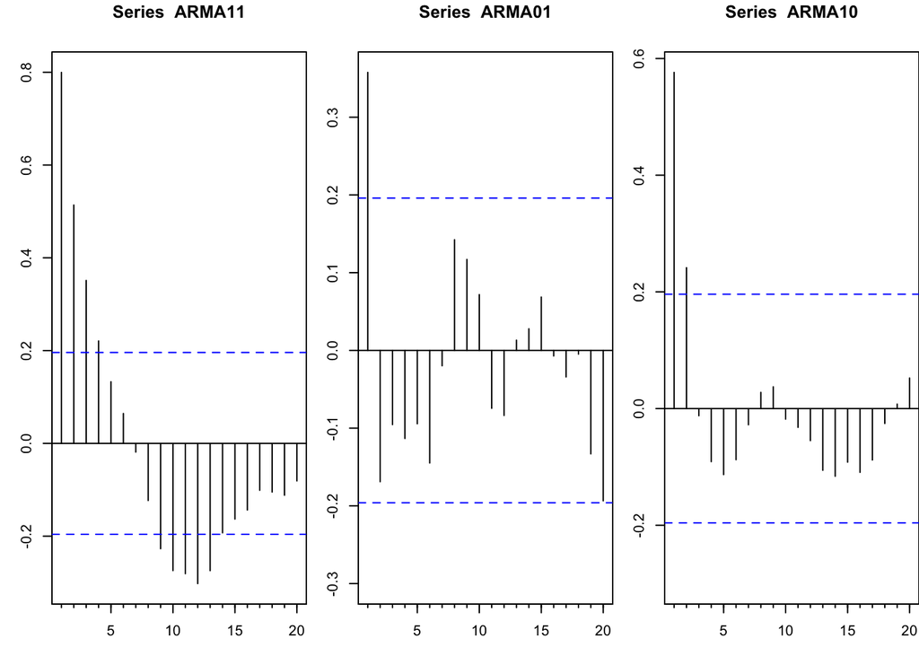

```r
par(mar=c(3,3,3,0));par(mfrow=c(1,3))
Acf(ARMA11, lag.max = NULL, plot = TRUE)
Acf(ARMA01, lag.max = NULL, plot = TRUE)
Acf(ARMA10, lag.max = NULL, plot = TRUE)
```

2. Plot the sample PACF for each of these models in one window to facilitate comparison.

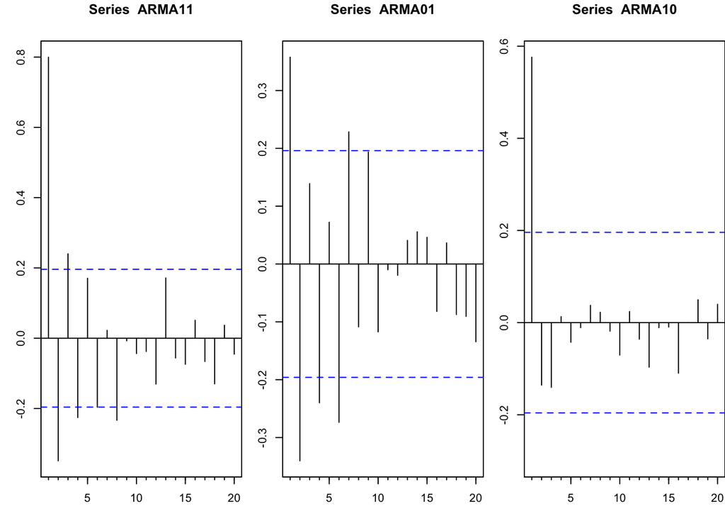

```r
par(mar=c(3,3,3,0));par(mfrow=c(1,3))
Pacf(ARMA11, lag.max = NULL, plot = TRUE)
Pacf(ARMA01, lag.max = NULL, plot = TRUE)
Pacf(ARMA10, lag.max = NULL, plot = TRUE)
```

3. Look at the ACFs and PACFs. Imagine you had these plots for a data set and you were asked to identify the model, i.e., is it AR, MA or ARMA and the order of each component. Would you be identify them correctly? Explain your answer.

> Answer: I would not identify them correctly. I may identify ARMA11 plot as AR process, because this series has positive autocorrelation at lag 1, and shows decay pattern in ACF plot. However, both ACF and PACF show slow decay. Hence, the ARMA (1,1) model would also be appropriate for the series. So I should experiment with both ARMA (1,1) and AR for the process and later select the optimal model. Base on plot, order = 4 ARMA01 pacf shows slow decay, but no nagetive autocorrelation at lag 1 in ACF, so it is hard to tell it is a MA process. ARMA10 ACF plot has positive autocorrelation at lag 1 and ACF shows sharp decay, AR terms work best, and order = 1.
4. Compare the ACF and PACF values R computed with the theoretical values you provided for the coefficients. Do they match? Explain your answer.

> Answer: I can only tell the phi in AR plot (third plot), which almost equals to theoretical values phi=0.6.
5. Increase number of observations to $n=1000$ and repeat parts (a)-(d).

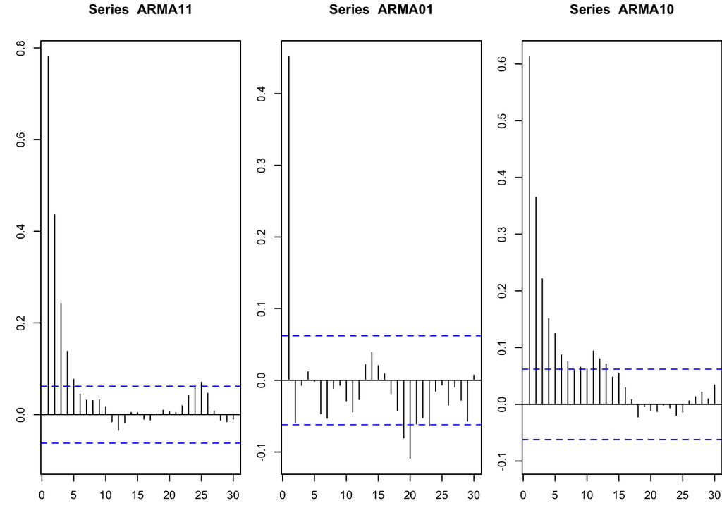

```r
set.seed(123)
ARMA11 <- arima.sim(model=list(ar=.6,ma=.9),n=1000)
ARMA01 <- arima.sim(model=list(ma=.9),n=1000)
ARMA10 <- arima.sim(model=list(ar=.6),n=1000)

#ACF
par(mar=c(3,3,3,0));par(mfrow=c(1,3))
Acf(ARMA11, lag.max = NULL, plot = TRUE)
Acf(ARMA01, lag.max = NULL, plot = TRUE)
Acf(ARMA10, lag.max = NULL, plot = TRUE)
```

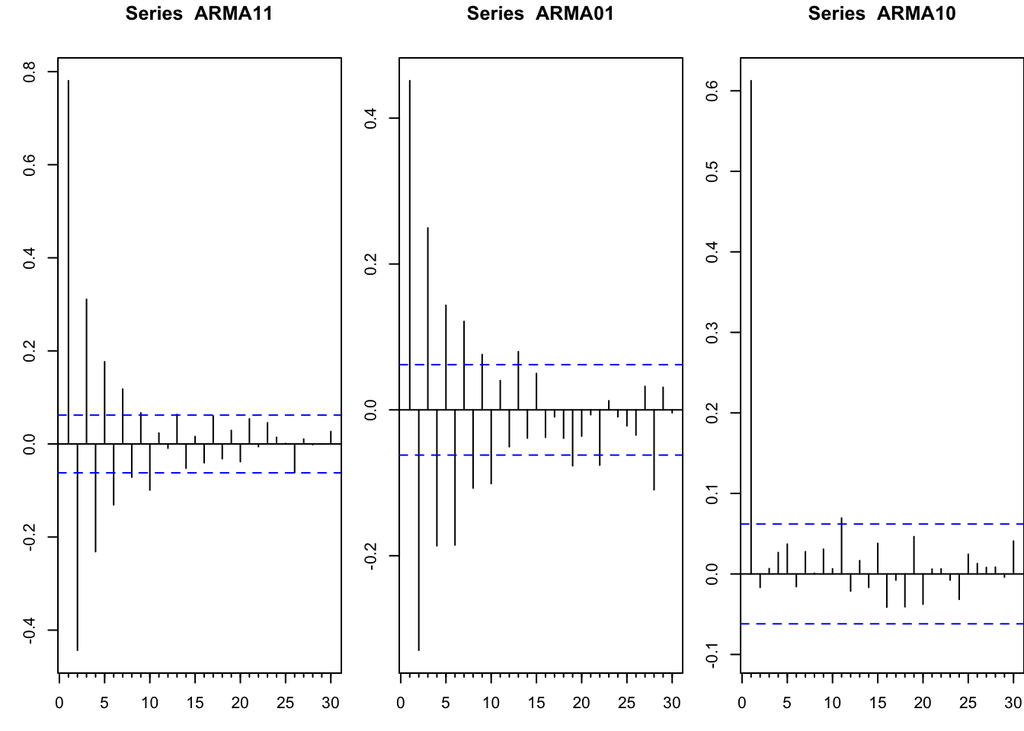

```r
#PACF
par(mar=c(3,3,3,0));par(mfrow=c(1,3))
Pacf(ARMA11, lag.max = NULL, plot = TRUE)
Pacf(ARMA01, lag.max = NULL, plot = TRUE)
Pacf(ARMA10, lag.max = NULL, plot = TRUE)
```

## Q3

Consider the ARIMA model $y_t=0.7*y_{t-1}-0.25*y_{t-12}+a_t-0.1*a_{t-1}$

1. Identify the model using the notation ARIMA$(p,d,q)(P,D,Q)_ s$, i.e., identify the integers $p,d,q,P,D,Q,s$ (if possible) from the equation.

> p = 1, d = 0, q = 1, P = 1, D = 0, Q = 0, s = 12 ARIMA(1,0,1)(1,0,0)12
2. Also from the equation what are the values of the parameters, i.e., model coefficients.

> phi1 = 0.7, phi12 = -0.25 and theta = -0.1

## Q4

Plot the ACF and PACF of a seasonal ARIMA$(0, 1)\times(1, 0)_{12}$ model with $\phi =0 .8$ and $\theta = 0.5$ using R. The $12$ after the bracket tells you that $s=12$, i.e., the seasonal lag is 12, suggesting monthly data whose behavior is repeated every 12 months. You can generate as many observations as you like. Note the Integrated part was omitted. It means the series do not need differencing, therefore $d=D=0$. Plot ACF and PACF for the simulated data. Comment if the plots are well representing the model you simulated, i.e., would you be able to identify the order of both non-seasonal and seasonal components from the plots? Explain.

```r
#install.packages(sarima)
#install.packages(glmnet)
#install.packages(bestglm)

#library(glmnet)
#library(bestglm)
library(sarima)
```

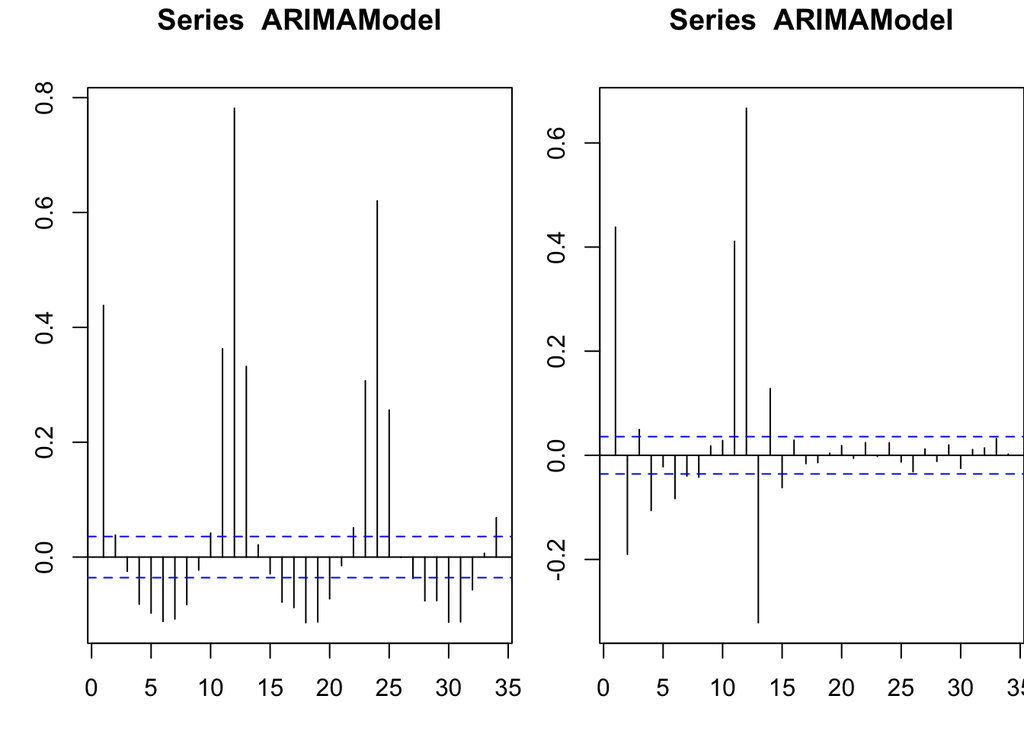

```r
#require("PolynomF")

# yt = phi ∗ yt−12 + at − theta ∗ at−1
set.seed(999)
ARIMAModel <- sim_sarima(n=3000, model = list(ar=0, ma=0.5, sar=0.8, sma=0, iorder=0, siorder=0, nseasons=12))

par(mar=c(3,3,3,0));par(mfrow=c(1,2))
Acf(ARIMAModel, lag.max = NULL)
Pacf(ARIMAModel, lag.max = NULL)
```